# Johns Hopkins University on Coursera

## Practical Machine Learning Course Project

by Ivan Ribeiro

## Introduction

Background

Using devices such as Jawbone Up, Nike FuelBand, and Fitbit it is now possible to collect a large amount of data about personal activity relatively inexpensively. These type of devices are part of the quantified self movement - a group of enthusiasts who take measurements about themselves regularly to improve their health, to find patterns in their behavior, or because they are tech geeks. One thing that people regularly do is quantify how much of a particular activity they do, but they rarely quantify how well they do it. In this project, your goal will be to use data from accelerometers on the belt, forearm, arm, and dumbell of 6 participants. They were asked to perform barbell lifts correctly and incorrectly in 5 different ways. More information is available from the website here: http://groupware.les.inf.puc-rio.br/har (see the section on the Weight Lifting Exercise Dataset).

Data

The training data for this project are available here:

https://d396qusza40orc.cloudfront.net/predmachlearn/pml-training.csv

The test data are available here:

https://d396qusza40orc.cloudfront.net/predmachlearn/pml-testing.csv

The data for this project come from this source: http://groupware.les.inf.puc-rio.br/har. If you use the document you create for this class for any purpose please cite them as they have been very generous in allowing their data to be used for this kind of assignment.

## Analysis

Thefollowing assumes the raw data files were download and are stored in th Working Directory.

The following packages are required for this analysis and are here loaded.

```r
library(rpart)
library(rpart.plot)
library(e1071)
library(caret)
library(RColorBrewer)
library(randomForest)
library(rattle)
```

Reading raw files.

```r
train <- read.csv("pml-training.csv", na.strings=c("NA","#DIV/0!",""))
test <- read.csv("pml-testing.csv", na.strings=c("NA","#DIV/0!",""))
```

To assure reproducibility:

```r
set.seed(88)
```

```r
TrainPart <- createDataPartition(y=train$classe, p=0.6, list=FALSE)
subtrain <- train[TrainPart, ]
subtest <- train[-TrainPart, ]
dim(subtrain)
```

```
## [1] 11776   160
```

```r
dim(subtest)
```

```
## [1] 7846  160
```

At this popint data is cleaned. Variables with near zero variance, variables with mostly missing data an variables unuseful as predictors are removed.

```r
subtrain2 <- subtrain
for (i in 1:length(subtrain)) {
  if (sum(is.na(subtrain[ , i])) / nrow(subtrain) >= .75) {
    for (j in 1:length(subtrain2)) {
      if (length(grep(names(subtrain[i]), names(subtrain2)[j]))==1) {
        subtrain2 <- subtrain2[ , -j]
      }
    }
  }
}

subtrain3 <- subtrain2[,8:length(subtrain2)]

NZV <- nearZeroVar(subtrain3, saveMetrics = TRUE)
NZV
```

```
##                      freqRatio percentUnique zeroVar   nzv
## roll_belt             1.021661    8.53430707   FALSE FALSE
## pitch_belt            1.008929   13.54449728   FALSE FALSE
## yaw_belt              1.015823   14.46161685   FALSE FALSE
## total_accel_belt      1.048222    0.22078804   FALSE FALSE
## gyros_belt_x          1.057143    1.06148098   FALSE FALSE
## gyros_belt_y          1.145337    0.52649457   FALSE FALSE
## gyros_belt_z          1.016651    1.31623641   FALSE FALSE
## accel_belt_x          1.027542    1.32472826   FALSE FALSE
## accel_belt_y          1.161184    1.15489130   FALSE FALSE
## accel_belt_z          1.070240    2.42017663   FALSE FALSE
## magnet_belt_x         1.196172    2.47112772   FALSE FALSE
## magnet_belt_y         1.068783    2.36922554   FALSE FALSE
## magnet_belt_z         1.043956    3.55808424   FALSE FALSE
## roll_arm             52.384615   19.54823370   FALSE FALSE
## pitch_arm            88.826087   22.56283967   FALSE FALSE
## yaw_arm              32.951613   21.31453804   FALSE FALSE
## total_accel_arm       1.003656    0.56046196   FALSE FALSE
## gyros_arm_x           1.003300    5.28192935   FALSE FALSE
## gyros_arm_y           1.367412    3.04857337   FALSE FALSE
## gyros_arm_z           1.072785    1.95312500   FALSE FALSE
## accel_arm_x           1.156863    6.39436141   FALSE FALSE
## accel_arm_y           1.190476    4.45822011   FALSE FALSE
## accel_arm_z           1.097222    6.31793478   FALSE FALSE
## magnet_arm_x          1.090909   11.10733696   FALSE FALSE
## magnet_arm_y          1.089286    7.29449728   FALSE FALSE
## magnet_arm_z          1.102941   10.52989130   FALSE FALSE
## roll_dumbbell         1.051282   87.59341033   FALSE FALSE
## pitch_dumbbell        2.365854   85.41949728   FALSE FALSE
## yaw_dumbbell          1.138889   87.00747283   FALSE FALSE
## total_accel_dumbbell  1.040049    0.35665761   FALSE FALSE
## gyros_dumbbell_x      1.035422    1.90217391   FALSE FALSE
## gyros_dumbbell_y      1.216216    2.23335598   FALSE FALSE
## gyros_dumbbell_z      1.102273    1.63043478   FALSE FALSE
## accel_dumbbell_x      1.010309    3.44769022   FALSE FALSE
## accel_dumbbell_y      1.034247    3.83831522   FALSE FALSE
## accel_dumbbell_z      1.142857    3.35427989   FALSE FALSE
## magnet_dumbbell_x     1.084906    8.80604620   FALSE FALSE
## magnet_dumbbell_y     1.267327    6.90387228   FALSE FALSE
## magnet_dumbbell_z     1.060870    5.53668478   FALSE FALSE
## roll_forearm         12.180412   14.98811141   FALSE FALSE
## pitch_forearm        67.485714   21.18716033   FALSE FALSE
## yaw_forearm          15.635762   14.30027174   FALSE FALSE
## total_accel_forearm   1.142276    0.56046196   FALSE FALSE
## gyros_forearm_x       1.127036    2.36922554   FALSE FALSE
## gyros_forearm_y       1.075893    6.01222826   FALSE FALSE
## gyros_forearm_z       1.177700    2.35224185   FALSE FALSE
## accel_forearm_x       1.072727    6.52173913   FALSE FALSE
## accel_forearm_y       1.067797    8.17764946   FALSE FALSE
## accel_forearm_z       1.000000    4.58559783   FALSE FALSE
## magnet_forearm_x      1.061224   12.09239130   FALSE FALSE
## magnet_forearm_y      1.156863   15.17493207   FALSE FALSE
## magnet_forearm_z      1.108108   13.23879076   FALSE FALSE
## classe                1.469065    0.04245924   FALSE FALSE
```

```r
clean1 <- colnames(subtrain3)
clean2 <- colnames(subtrain3[, -53]) #to remove classe
subtest <- subtrain3[clean1]
test <- test[clean2]
dim(subtest)
```

```
## [1] 11776    53
```

```r
dim(test)
```

```
## [1] 20 52
```

```r
Fit1 <- rpart(classe ~ ., data=subtrain3, method="class")
print(Fit1)
```

```
## n= 11776
##
## node), split, n, loss, yval, (yprob)
##       * denotes terminal node
##
##     1) root 11776 8428 A (0.28 0.19 0.17 0.16 0.18)
##       2) roll_belt< 130.5 10780 7444 A (0.31 0.21 0.19 0.18 0.11)
##         4) pitch_forearm< -33.95 936   10 A (0.99 0.011 0 0 0) *
##         5) pitch_forearm>=-33.95 9844 7434 A (0.24 0.23 0.21 0.2 0.12)
##          10) magnet_dumbbell_y< 433.5 8244 5895 A (0.28 0.18 0.24 0.19 0.11)
##            20) roll_forearm< 123.5 5130 3026 A (0.41 0.18 0.18 0.17 0.061)
##              40) magnet_dumbbell_z< -24.5 1790  578 A (0.68 0.2 0.02 0.073 0.033) *
##              41) magnet_dumbbell_z>=-24.5 3340 2440 C (0.27 0.17 0.27 0.22 0.075)
##                82) yaw_belt>=168.5 437   73 A (0.83 0.085 0.0023 0.076 0.0046) *
##                83) yaw_belt< 168.5 2903 2004 C (0.18 0.18 0.31 0.24 0.086)
##                 166) pitch_belt< -42.85 307   54 B (0.023 0.82 0.1 0.023 0.029) *
##                 167) pitch_belt>=-42.85 2596 1728 C (0.2 0.11 0.33 0.27 0.093)
##                   334) accel_dumbbell_y>=-40.5 2217 1543 D (0.23 0.12 0.24 0.3 0.1)
##                     668) roll_belt>=125.5 528  212 C (0.37 0.023 0.6 0.0076 0.0038)
##                      1336) magnet_belt_z< -323 170    6 A (0.96 0 0.024 0 0.012) *
##                      1337) magnet_belt_z>=-323 358   46 C (0.084 0.034 0.87 0.011 0) *
##                     669) roll_belt< 125.5 1689 1019 D (0.19 0.15 0.13 0.4 0.13)
##                      1338) pitch_belt>=0.93 1062  823 A (0.23 0.22 0.15 0.22 0.19)
##                        2676) accel_dumbbell_z< 25.5 663  438 A (0.34 0.13 0.24 0.26 0.033)
##                          5352) yaw_forearm>=-94.65 477  252 A (0.47 0.17 0.26 0.059 0.034)
##                           10704) magnet_forearm_z>=-108.5 301   80 A (0.73 0.15 0.023 0.066 0.03) *
##                           10705) magnet_forearm_z< -108.5 176   58 C (0.023 0.22 0.67 0.045 0.04) *
##                          5353) yaw_forearm< -94.65 186   41 D (0 0.016 0.17 0.78 0.032) *
##                        2677) accel_dumbbell_z>=25.5 399  221 E (0.035 0.37 0.005 0.14 0.45)
##                          5354) roll_dumbbell< 38.68377 149   29 B (0.034 0.81 0.013 0.02 0.13) *
##                          5355) roll_dumbbell>=38.68377 250   91 E (0.036 0.11 0 0.22 0.64) *
##                      1339) pitch_belt< 0.93 627  187 D (0.14 0.026 0.096 0.7 0.04)
##                        2678) yaw_arm< -110.55 85    0 A (1 0 0 0 0) *
##                        2679) yaw_arm>=-110.55 542  102 D (0.0018 0.03 0.11 0.81 0.046) *
##                   335) accel_dumbbell_y< -40.5 379   46 C (0.0053 0.04 0.88 0.04 0.037) *
##            21) roll_forearm>=123.5 3114 2061 C (0.079 0.17 0.34 0.23 0.18)
##              42) magnet_dumbbell_y< 292.5 1846  936 C (0.093 0.12 0.49 0.15 0.14)
##                84) magnet_forearm_z< -263 134   21 A (0.84 0.052 0 0.045 0.06) *
##                85) magnet_forearm_z>=-263 1712  802 C (0.034 0.13 0.53 0.16 0.15) *
##              43) magnet_dumbbell_y>=292.5 1268  832 D (0.058 0.25 0.11 0.34 0.24)
##                86) accel_forearm_x>=-102.5 820  547 E (0.049 0.31 0.16 0.15 0.33)
##                 172) magnet_arm_y>=181.5 333  149 B (0.006 0.55 0.24 0.096 0.11) *
##                 173) magnet_arm_y< 181.5 487  250 E (0.078 0.14 0.11 0.18 0.49) *
##                87) accel_forearm_x< -102.5 448  131 D (0.074 0.13 0.018 0.71 0.071) *
##          11) magnet_dumbbell_y>=433.5 1600  787 B (0.038 0.51 0.041 0.22 0.19)
##            22) total_accel_dumbbell>=5.5 1147  405 B (0.053 0.65 0.056 0.028 0.22)
##              44) roll_belt>=-0.58 978  236 B (0.062 0.76 0.065 0.033 0.081) *
##              45) roll_belt< -0.58 169    0 E (0 0 0 0 1) *
##            23) total_accel_dumbbell< 5.5 453  125 D (0 0.16 0.0044 0.72 0.11) *
##       3) roll_belt>=130.5 996   12 E (0.012 0 0 0 0.99) *
```

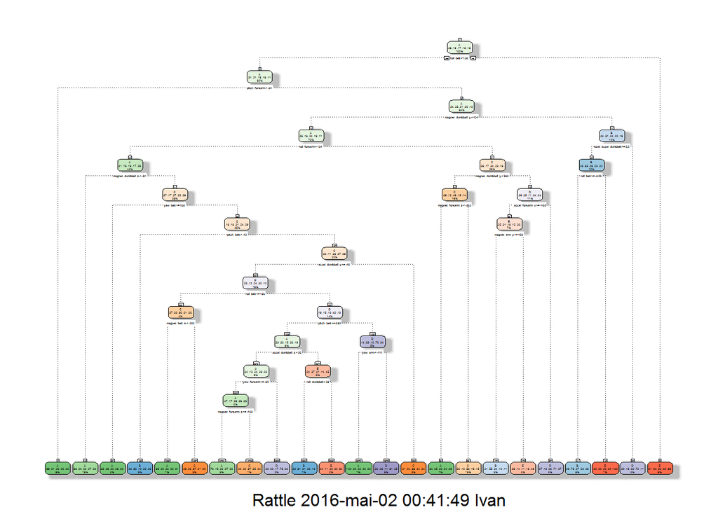

```r
fancyRpartPlot(Fit1)
```

```r
Predict1 <- predict(Fit1, subtrain3, type = "class")
confusionMatrix(Predict1, subtest$classe)
```

```
## Confusion Matrix and Statistics
##
##           Reference
## Prediction    A    B    C    D    E
##          A 3085  452   47  189   80
##          B   75 1299  176   74  143
##          C   95  283 1673  296  278
##          D   34  148  102 1230  115
##          E   59   97   56  141 1549
##
## Overall Statistics
##
##                Accuracy : 0.7503
##                  95% CI : (0.7424, 0.7581)
##     No Information Rate : 0.2843
##     P-Value [Acc > NIR] : < 2.2e-16
##
##                   Kappa : 0.6826
##  Mcnemar's Test P-Value : < 2.2e-16
##
## Statistics by Class:
##
##                      Class: A Class: B Class: C Class: D Class: E
## Sensitivity            0.9214   0.5700   0.8145   0.6373   0.7155
## Specificity            0.9089   0.9507   0.9021   0.9595   0.9633
## Pos Pred Value         0.8007   0.7351   0.6373   0.7551   0.8144
## Neg Pred Value         0.9668   0.9021   0.9584   0.9310   0.9376
## Prevalence             0.2843   0.1935   0.1744   0.1639   0.1838
## Detection Rate         0.2620   0.1103   0.1421   0.1044   0.1315
## Detection Prevalence   0.3272   0.1501   0.2229   0.1383   0.1615
## Balanced Accuracy      0.9152   0.7604   0.8583   0.7984   0.8394
```

```r
Fit2 <- randomForest(classe ~. , data=subtrain3)
print(Fit2)
```

```
##
## Call:
##  randomForest(formula = classe ~ ., data = subtrain3)
##                Type of random forest: classification
##                      Number of trees: 500
## No. of variables tried at each split: 7
##
##         OOB estimate of  error rate: 0.77%
## Confusion matrix:
##      A    B    C    D    E class.error
## A 3344    3    0    0    1 0.001194743
## B   17 2254    8    0    0 0.010969724
## C    0   18 2033    3    0 0.010223953
## D    0    0   28 1900    2 0.015544041
## E    0    0    2    9 2154 0.005080831
```

```r
Predict2 <- predict(Fit2, subtest, type = "class")
confusionMatrix(Predict2, subtest$classe)
```

```
## Confusion Matrix and Statistics
##
##           Reference
## Prediction    A    B    C    D    E
##          A 3348    0    0    0    0
##          B    0 2279    0    0    0
##          C    0    0 2054    0    0
##          D    0    0    0 1930    0
##          E    0    0    0    0 2165
##
## Overall Statistics
##
##                Accuracy : 1
##                  95% CI : (0.9997, 1)
##     No Information Rate : 0.2843
##     P-Value [Acc > NIR] : < 2.2e-16
##
##                   Kappa : 1
##  Mcnemar's Test P-Value : NA
##
## Statistics by Class:
##
##                      Class: A Class: B Class: C Class: D Class: E
## Sensitivity            1.0000   1.0000   1.0000   1.0000   1.0000
## Specificity            1.0000   1.0000   1.0000   1.0000   1.0000
## Pos Pred Value         1.0000   1.0000   1.0000   1.0000   1.0000
## Neg Pred Value         1.0000   1.0000   1.0000   1.0000   1.0000
## Prevalence             0.2843   0.1935   0.1744   0.1639   0.1838
## Detection Rate         0.2843   0.1935   0.1744   0.1639   0.1838
## Detection Prevalence   0.2843   0.1935   0.1744   0.1639   0.1838
## Balanced Accuracy      1.0000   1.0000   1.0000   1.0000   1.0000
```